# ExtraaLearn Project

## Context

The EdTech industry has been surging in the past decade immensely, and according to a forecast, the Online Education market would be worth $286.62bn by 2023 with a compound annual growth rate (CAGR) of 10.26% from 2018 to 2023. The modern era of online education has enforced a lot in its growth and expansion beyond any limit. Due to having many dominant features like ease of information sharing, personalized learning experience, transparency of assessment, etc, it is now preferable to traditional education.

In the present scenario due to the Covid-19, the online education sector has witnessed rapid growth and is attracting a lot of new customers. Due to this rapid growth, many new companies have emerged in this industry. With the availability and ease of use of digital marketing resources, companies can reach out to a wider audience with their offerings. The customers who show interest in these offerings are termed as leads. There are various sources of obtaining leads for Edtech companies, like

- The customer interacts with the marketing front on social media or other online platforms.
- The customer browses the website/app and downloads the brochure
- The customer connects through emails for more information.

The company then nurtures these leads and tries to convert them to paid customers. For this, the representative from the organization connects with the lead on call or through email to share further details.

## Objective

ExtraaLearn is an initial stage startup that offers programs on cutting-edge technologies to students and professionals to help them upskill/reskill. With a large number of leads being generated regularly, one of the issues faced by ExtraaLearn is to identify which of the leads are more likely to convert so that they can allocate resources accordingly. You, as a data scientist at ExtraaLearn, have been provided the leads data to:

- Analyze and build an ML model to help identify which leads are more likely to convert to paid customers,
- Find the factors driving the lead conversion process
- Create a profile of the leads which are likely to convert

## Data Description

The data contains the different attributes of leads and their interaction details with ExtraaLearn. The detailed data dictionary is given below.

**Data Dictionary**

- ID: ID of the lead
- age: Age of the lead
- current_occupation: Current occupation of the lead. Values include 'Professional','Unemployed',and 'Student'
- first_interaction: How did the lead first interact with ExtraaLearn. Values include 'Website', 'Mobile App'
- profile_completed: What percentage of the profile has been filled by the lead on the website/mobile app. Values include Low - (0-50%), Medium - (50-75%), High (75-100%)
- website_visits: How many times has a lead visited the website
- time_spent_on_website: Total time spent on the website
- page_views_per_visit: Average number of pages on the website viewed during the visits.
- last_activity: Last interaction between the lead and ExtraaLearn.
  - Email Activity: Seeking for details about the program through email, Representative shared information with a lead like a brochure of program, etc
  - Phone Activity: Had a Phone Conversation with a representative, Had conversation over SMS with a representative, etc
  - Website Activity: Interacted on live chat with a representative, Updated profile on the website, etc
- print_media_type1: Flag indicating whether the lead had seen the ad of ExtraaLearn in the Newspaper.
- print_media_type2: Flag indicating whether the lead had seen the ad of ExtraaLearn in the Magazine.
- digital_media: Flag indicating whether the lead had seen the ad of ExtraaLearn on the digital platforms.
- educational_channels: Flag indicating whether the lead had heard about ExtraaLearn in the education channels like online forums, discussion threads, educational websites, etc.
- referral: Flag indicating whether the lead had heard about ExtraaLearn through reference.
- status: Flag indicating whether the lead was converted to a paid customer or not.

## Import Dataset

### View the first and last 5 rows of the dataset

|  | ID | age | current_occupation | first_interaction | profile_completed | website_visits | time_spent_on_website | page_views_per_visit | last_activity | print_media_type1 | print_media_type2 | digital_media | educational_channels | referral | status |
| --- | --- | --- | --- | --- | --- | --- | --- | --- | --- | --- | --- | --- | --- | --- | --- |
| 0 | EXT001 | 57 | Unemployed | Website | High | 7 | 1639 | 1.86100 | Website Activity | Yes | No | Yes | No | No | 1 |
| 1 | EXT002 | 56 | Professional | Mobile App | Medium | 2 | 83 | 0.32000 | Website Activity | No | No | No | Yes | No | 0 |
| 2 | EXT003 | 52 | Professional | Website | Medium | 3 | 330 | 0.07400 | Website Activity | No | No | Yes | No | No | 0 |
| 3 | EXT004 | 53 | Unemployed | Website | High | 4 | 464 | 2.05700 | Website Activity | No | No | No | No | No | 1 |
| 4 | EXT005 | 23 | Student | Website | High | 4 | 600 | 16.91400 | Email Activity | No | No | No | No | No | 0 |

|  | ID | age | current_occupation | first_interaction | profile_completed | website_visits | time_spent_on_website | page_views_per_visit | last_activity | print_media_type1 | print_media_type2 | digital_media | educational_channels | referral | status |
| --- | --- | --- | --- | --- | --- | --- | --- | --- | --- | --- | --- | --- | --- | --- | --- |
| 4607 | EXT4608 | 35 | Unemployed | Mobile App | Medium | 15 | 360 | 2.17000 | Phone Activity | No | No | No | Yes | No | 0 |
| 4608 | EXT4609 | 55 | Professional | Mobile App | Medium | 8 | 2327 | 5.39300 | Email Activity | No | No | No | No | No | 0 |
| 4609 | EXT4610 | 58 | Professional | Website | High | 2 | 212 | 2.69200 | Email Activity | No | No | No | No | No | 1 |
| 4610 | EXT4611 | 57 | Professional | Mobile App | Medium | 1 | 154 | 3.87900 | Website Activity | Yes | No | No | No | No | 0 |
| 4611 | EXT4612 | 55 | Professional | Website | Medium | 4 | 2290 | 2.07500 | Phone Activity | No | No | No | No | No | 0 |

### Understand the shape of the dataset

```
(4612, 15)
```

### Check the data types of the columns for the dataset

```
<class 'pandas.core.frame.DataFrame'>
RangeIndex: 4612 entries, 0 to 4611
Data columns (total 15 columns):
 #   Column                 Non-Null Count  Dtype
---  ------                 --------------  -----
 0   ID                     4612 non-null   object
 1   age                    4612 non-null   int64
 2   current_occupation     4612 non-null   object
 3   first_interaction      4612 non-null   object
 4   profile_completed      4612 non-null   object
 5   website_visits         4612 non-null   int64
 6   time_spent_on_website  4612 non-null   int64
 7   page_views_per_visit   4612 non-null   float64
 8   last_activity          4612 non-null   object
 9   print_media_type1      4612 non-null   object
 10  print_media_type2      4612 non-null   object
 11  digital_media          4612 non-null   object
 12  educational_channels   4612 non-null   object
 13  referral               4612 non-null   object
 14  status                 4612 non-null   int64
dtypes: float64(1), int64(4), object(10)
memory usage: 540.6+ KB
```

```
np.int64(0)
```

## Exploratory Data Analysis

**Let's check the statistical summary of the data.**

|  | age | website_visits | time_spent_on_website | page_views_per_visit | status |
| --- | --- | --- | --- | --- | --- |
| count | 4612.00000 | 4612.00000 | 4612.00000 | 4612.00000 | 4612.00000 |
| mean | 46.20121 | 3.56678 | 724.01127 | 3.02613 | 0.29857 |
| std | 13.16145 | 2.82913 | 743.82868 | 1.96812 | 0.45768 |
| min | 18.00000 | 0.00000 | 0.00000 | 0.00000 | 0.00000 |
| 25% | 36.00000 | 2.00000 | 148.75000 | 2.07775 | 0.00000 |
| 50% | 51.00000 | 3.00000 | 376.00000 | 2.79200 | 0.00000 |
| 75% | 57.00000 | 5.00000 | 1336.75000 | 3.75625 | 1.00000 |
| max | 63.00000 | 30.00000 | 2537.00000 | 18.43400 | 1.00000 |

```
ID
EXT4612    1
EXT001     1
EXT002     1
EXT003     1
EXT4596    1
          ..
EXT009     1
EXT008     1
EXT007     1
EXT006     1
EXT005     1
Name: count, Length: 4612, dtype: int64
--------------------------------------------------
current_occupation
Professional    2616
Unemployed      1441
Student          555
Name: count, dtype: int64
--------------------------------------------------
first_interaction
Website       2542
Mobile App    2070
Name: count, dtype: int64
--------------------------------------------------
profile_completed
High      2264
Medium    2241
Low        107
Name: count, dtype: int64
--------------------------------------------------
last_activity
Email Activity      2278
Phone Activity      1234
Website Activity    1100
Name: count, dtype: int64
--------------------------------------------------
print_media_type1
No     4115
Yes     497
Name: count, dtype: int64
--------------------------------------------------
print_media_type2
No     4379
Yes     233
Name: count, dtype: int64
--------------------------------------------------
digital_media
No     4085
Yes     527
Name: count, dtype: int64
--------------------------------------------------
educational_channels
No     3907
Yes     705
Name: count, dtype: int64
--------------------------------------------------
referral
No     4519
Yes      93
Name: count, dtype: int64
--------------------------------------------------
```

```
4612
```

### Observations on age

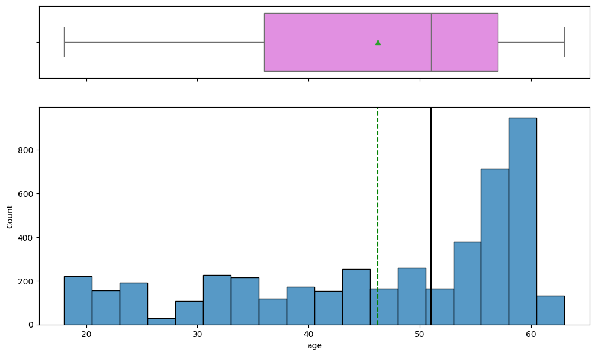

### Observations on website_visits

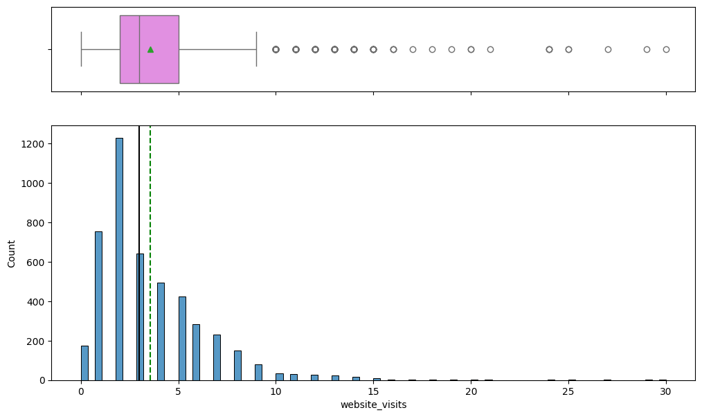

```
(174, 14)
```

### Observations on number of time_spent_on_website

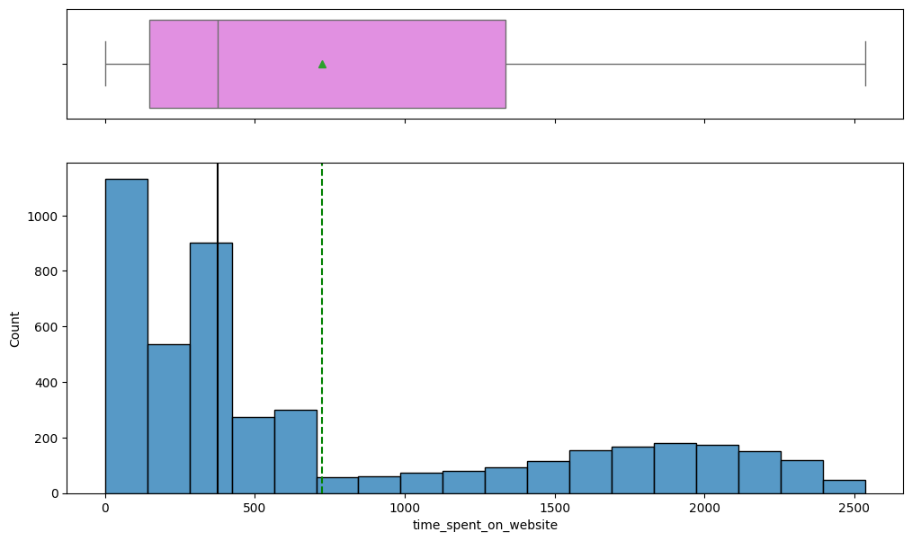

### Observations on number of page_views_per_visit

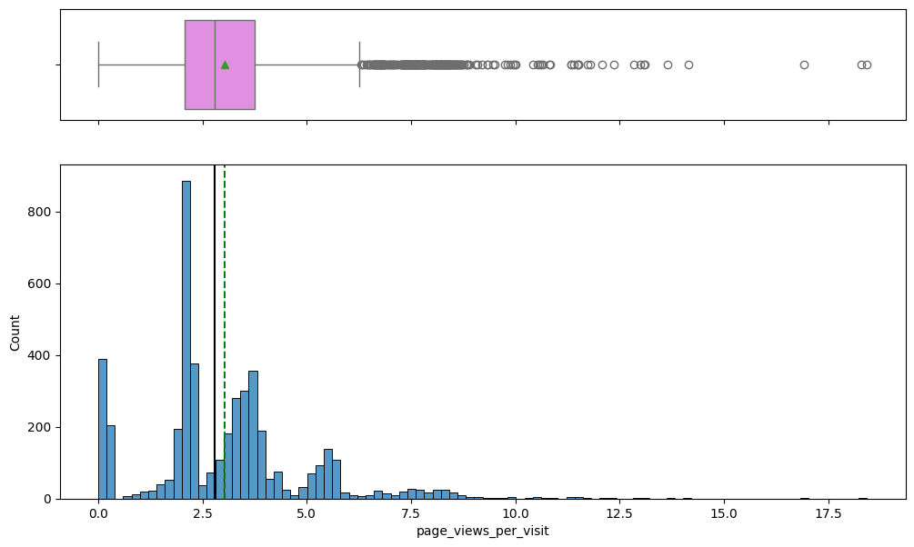

### Observations on current_occupation

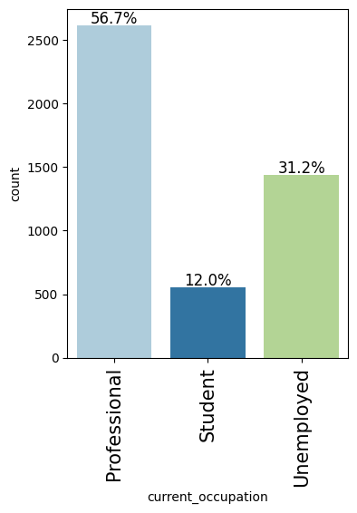

### Observations on number of first_interaction

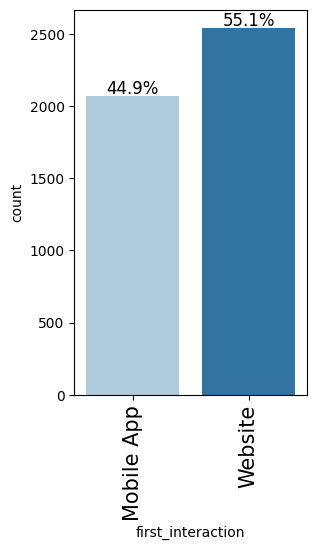

### Observations on profile_completed

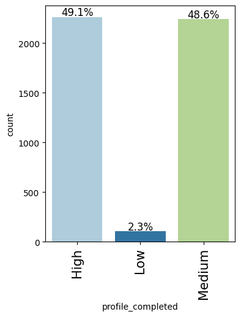

### Observations on last_activity

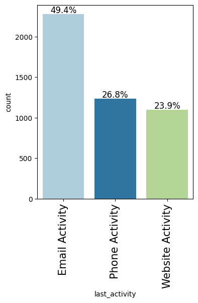

### Observations on print_media_type1

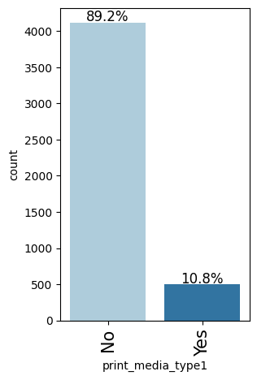

### Observations on print_media_type2

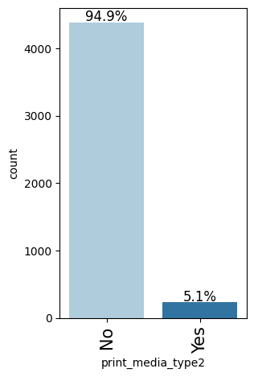

### Observations on digital_media

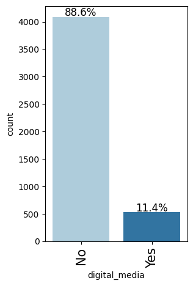

### Observations on educational_channels

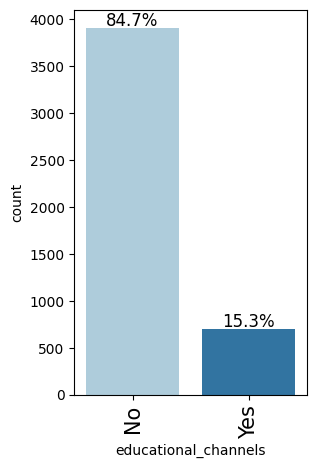

### Observations on referral

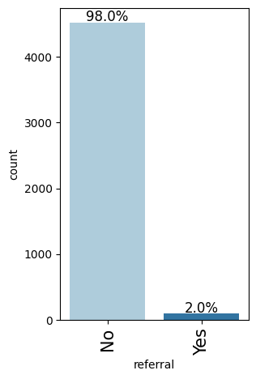

### Observations on status

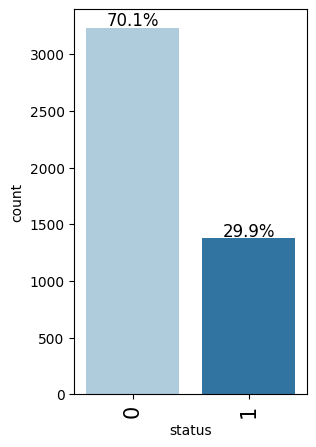

**Observations from Univariate Analysis:**

Age:

- Distribution of age is skewed left.
- Most of the customers are over 50 years old.

Website visits:

Time spent on website:

- The distribution is highly right-skewed.
- Most of the leads spent less than 500s on the website, but there is a small group of people who spent a lot of time, which may show special interest.
- The median and mean differ, which emphasizes the asymmetry of the layout.
- In the future section, we should check how time spent on the site correlates with conversion.

Page views per visit:

- The distribution is skewed towards the right.
- The data are unevenly distributed.
- There are many outliers in this variable, and the values above 6 are represented as outliers in the boxplot.

Current occupation:

- Most potential customers are professionally active. This may suggest that this group is more interested in the company's offer or browses the website more often.

First indication:

- First indication is mostly through the website.

Profile completed:

- Nearly all profiles are completed at a medium or high level, which means that they are filled by the lead over 50%.

Last activity:

- The dominant form of contact was email activity. It can mean that the leads prefer less direct contact or the company uses emails more intensively in their sales strategy.

Print media type:

- Only 15.9% of the leads have seen the company's ad in a newspaper or magazine.

Digital media:

- 11.4% of of the leads have seen the company's ad in digital media.

Referral:

- Only 2% of leads heard about the company by reference.

Status:

- 30% of the leads were converted to paying customers, which is a relatively high percentage.

### Bivariate Analysis

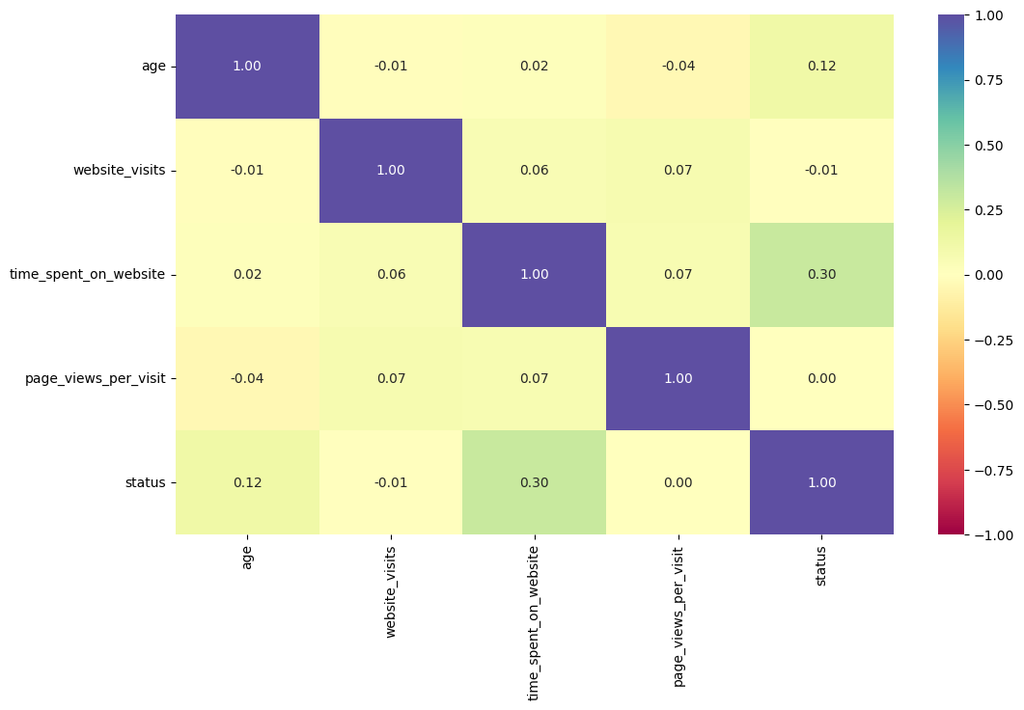

**Creating functions that will help us with further analysis.**

**Leads will have different expectations from the outcome of the course and the current occupation may play a key role for them to take the program. Let's analyze it**

```
status                 0     1   All
current_occupation
All                 3235  1377  4612
Professional        1687   929  2616
Unemployed          1058   383  1441
Student              490    65   555
------------------------------------------------------------------------------------------------------------------------
```

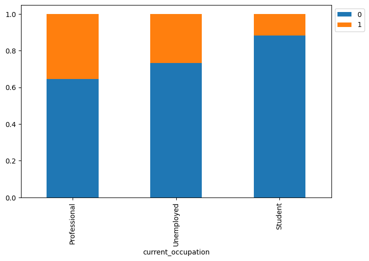

**Age can be a good factor to differentiate between such leads**

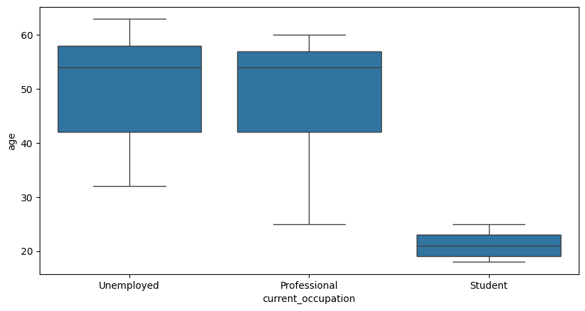

| current_occupation | count | mean | std | min | 25% | 50% | 75% | max |
| --- | --- | --- | --- | --- | --- | --- | --- | --- |
| Professional | 2616.00000 | 49.34748 | 9.89074 | 25.00000 | 42.00000 | 54.00000 | 57.00000 | 60.00000 |
| Student | 555.00000 | 21.14414 | 2.00111 | 18.00000 | 19.00000 | 21.00000 | 23.00000 | 25.00000 |
| Unemployed | 1441.00000 | 50.14018 | 9.99950 | 32.00000 | 42.00000 | 54.00000 | 58.00000 | 63.00000 |

**The company's first interaction with leads should be compelling and persuasive. Let's see if the channels of the first interaction have an impact on the conversion of leads**

```
status                0     1   All
first_interaction
All                3235  1377  4612
Website            1383  1159  2542
Mobile App         1852   218  2070
------------------------------------------------------------------------------------------------------------------------
```

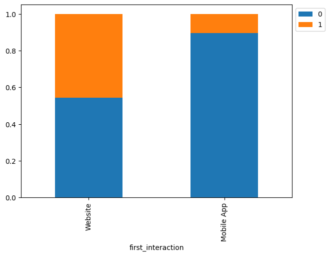

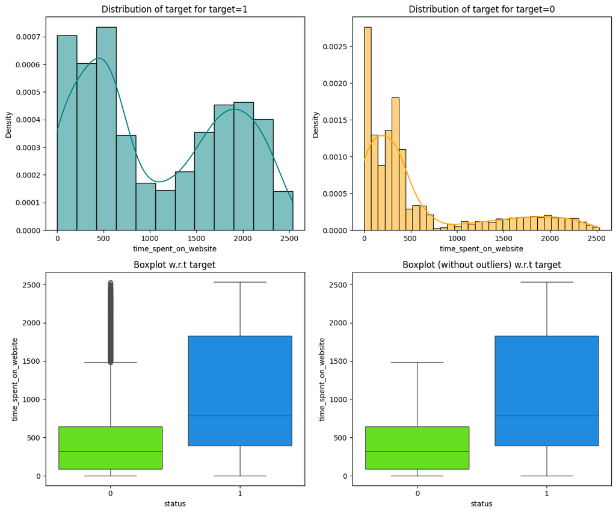

| status | time_spent_on_website |
| --- | --- |
| 0 | 317.00000 |
| 1 | 789.00000 |

**dtype:** float64

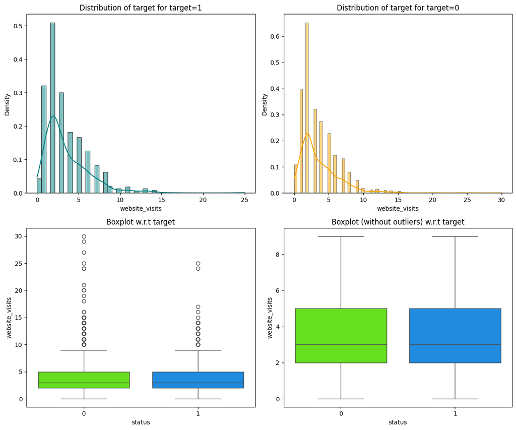

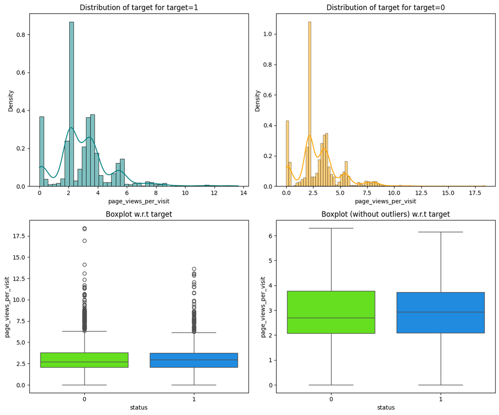

**People browsing the website or the mobile app are generally required to create a profile by sharing their personal details before they can access more information. Let's see if the profile completion level has an impact on lead status**

```
status                0     1   All
profile_completed
All                3235  1377  4612
High               1318   946  2264
Medium             1818   423  2241
Low                  99     8   107
------------------------------------------------------------------------------------------------------------------------
```

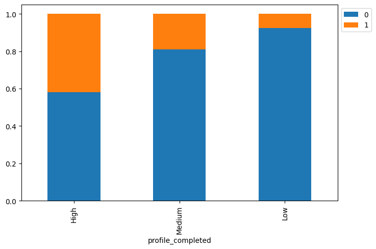

**After a lead shares their information by creating a profile, there may be interactions between the lead and the company to proceed with the process of enrollment. Let's see how the last activity impacts lead conversion status**

```
status               0     1   All
last_activity
All               3235  1377  4612
Email Activity    1587   691  2278
Website Activity   677   423  1100
Phone Activity     971   263  1234
------------------------------------------------------------------------------------------------------------------------
```

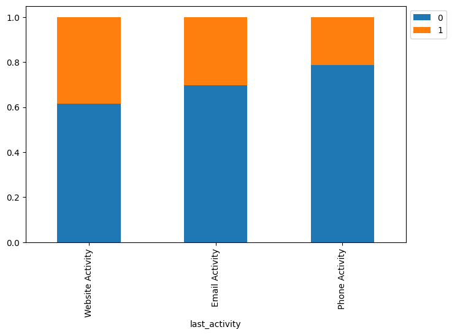

**Let's see how advertisement and referrals impact the lead status**

```
status                0     1   All
print_media_type1
All                3235  1377  4612
No                 2897  1218  4115
Yes                 338   159   497
------------------------------------------------------------------------------------------------------------------------
```

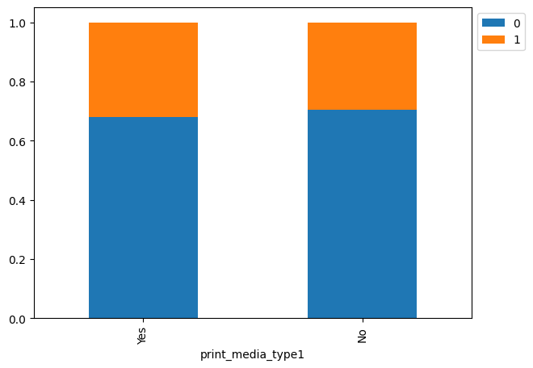

```
status                0     1   All
print_media_type2
All                3235  1377  4612
No                 3077  1302  4379
Yes                 158    75   233
------------------------------------------------------------------------------------------------------------------------
```

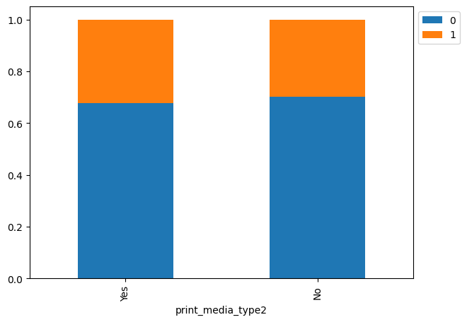

```
status            0     1   All
digital_media
All            3235  1377  4612
No             2876  1209  4085
Yes             359   168   527
------------------------------------------------------------------------------------------------------------------------
```

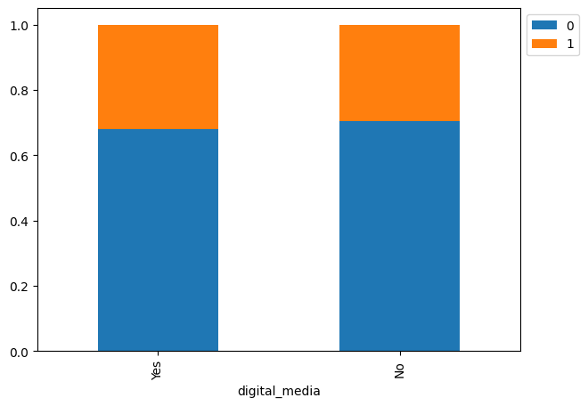

```
status                   0     1   All
educational_channels
All                   3235  1377  4612
No                    2727  1180  3907
Yes                    508   197   705
------------------------------------------------------------------------------------------------------------------------
```

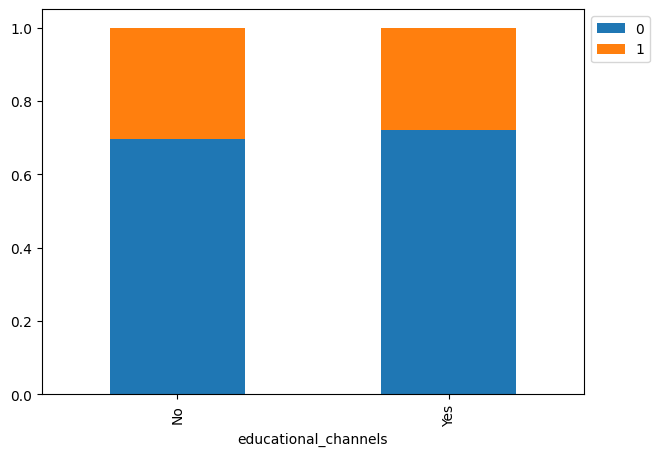

```
status       0     1   All
referral
All       3235  1377  4612
No        3205  1314  4519
Yes         30    63    93
------------------------------------------------------------------------------------------------------------------------
```

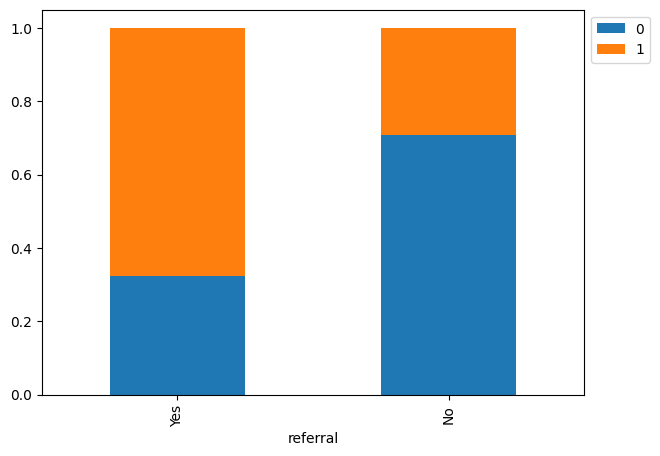

### Outlier Check

- Let's check for outliers in the data.

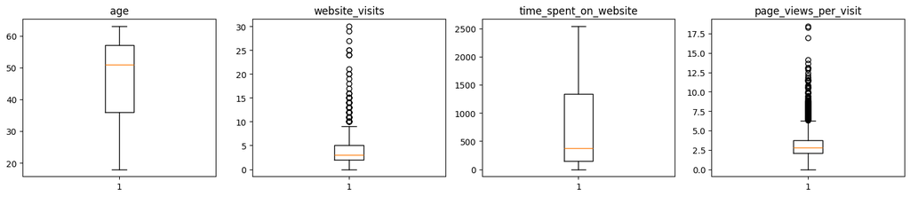

**Observations:**

Correlation: The most significant correlation observed is between time spent on the website and conversion status. This indicates a positive relationship, the more time a lead spends on the website, the higher the probability of conversion.

Occupation:

- Professionals are significantly more likely to convert compared to students and unemployed leads.
- This may indicate higher purchasing power, stronger motivation for career development, or greater engagement with the offer.

First interaction:

- First interaction appears to have a considerable impact on lead behavior and eventual conversion -Leads whose first interaction occurred via the website converted at a rate of 46%, compared to only 11% for those who first interacted through the mobile app. -Leads from the website are more than four times more likely to convert than those from the mobile app.

Time spent on website:

- This is the strongest behavioral indicator of conversion.
- Converted leads spent significantly more time on the site (median: 789 vs. 317 for non-converted).
- This indicates that users who eventually converted spent more time browsing the website, possibly showing higher interest or engagement.
- Therefore, time spent on website is a strong predictor of conversion and should be treated as a key behavioral indicator in further modeling or segmentation.

Page views per visit:

- A large number of outliers were observed regardless of status, especially above 6 page views.
- It doesn't correlate with, conversion.

Profile Completion:

- A strong positive correlation exists between profile completion level and conversion, which may indicate their greater involvement and interest in the offer.
- It is worth treating the level of profile completion as an important predictor of conversion in further analyses.

Last Activity:

- The most effective last activity in terms of conversion was website activity with a conversion rate of 38.5%.
- Phone activity had the lowest conversion rate, which may indicate it is a less effective method of final engagement.
- Email activity, which is the most common final touchpoint (nearly 50% of cases), had a conversion rate of 30%, close to the overall average.
- These insights suggest that website interaction is a more valuable indicator of purchase intent than traditional phone or email follow-ups.

Marketing activities:

- Initial observation shows that exposure to marketing channels has a slightly positive impact on conversion, although the effect is not large:
- in case of Newspaper, acquired leads has 32% of conversion rate instead of 29,6% who didn't see the advertisement.
- in case of Magazine acquired leads has 32,2% of conversion rate instead of 30% who didn't see the advertisement.
- in case of Digital Media acquired leads has 31,9% of conversion rate instead of 30% who didn't see the advertisement.
- To summarise the differences is not big but it may suggest a positive impact of marketing activities on conversion.

Education channels:

- Leads who discovered the company through the internet have a slightly lower conversion rate (28%) compared to others (30%+). -This may be due to high competition, advertising noise, or lower trust.

Referral:

- Referral increase conversion rate by more than twice (67,7%).
- This makes referrals one of the most valuable and effective lead sources.
- The company should strongly consider expanding referral programs.

Outlaiers:

- Outliers were observed in two numerical variables: Website Visits (above 10 visits) and Page Views per Visit (above 6 pages).
- These values, although outside the interquartile range, are not necessarily unrealistic

### Data Preparation for modeling

- We want to predict which lead is more likely to be converted.
- Before we proceed to build a model, we'll have to encode categorical features.
- We'll split the data into train and test to be able to evaluate the model that we build on the train data.

```
Shape of Training set :  (3228, 16)
Shape of test set :  (1384, 16)
Percentage of classes in training set:
status
0   0.70415
1   0.29585
Name: proportion, dtype: float64
Percentage of classes in test set:
status
0   0.69509
1   0.30491
Name: proportion, dtype: float64
```

## **Building Classification Models**

### Model evaluation criterion

### Model can make wrong predictions as:

1. Predicting a lead will not be converted to a paid customer in reality, the lead would have converted to a paid customer.
2. Predicting a lead will be converted to a paid customer in reality, the lead would not have converted to a paid customer.

### Which case is more important?

- If we predict that a lead will not get converted and the lead would have converted then the company will lose a potential customer.
- If we predict that a lead will get converted and the lead doesn't get converted the company might lose resources by nurturing false-positive cases.

Losing a potential customer is a greater loss.

### How to reduce the losses?

- Company would want `Recall` to be maximized, greater the Recall score higher are the chances of minimizing False Negatives.

#### First, let's create functions to calculate different metrics and confusion matrix so that we don't have to use the same code repeatedly for each model.

- The model_performance_classification_statsmodels function will be used to check the model performance of models.
- The confusion_matrix_statsmodels function will be used to plot the confusion matrix.